# Cryptography 2

Autumn 2025

## Public Key Cryptography

## Perfect Secrecy

- We have seen that ciphers can be broken.
- Most of these methods of decryption rely on spotting patterns in the ciphertext (e.g., Viginere).
- If a secret key is used only once, and has the same length as the ciphertext, we have perfect secrecy.
- Called “one time pad”.
- In reality, the best we can do is to ensure that brute force is the fastest way to break our cipher.

## The key exchange problem

- Alice and Bob want to exchange private messages.
- Oscar, a bad actor, wants to eaves-drop on Alice and Bob’s conversation.
- Alice and Bob could use a cipher, e.g., AES, which produces ciphertext unreadable by Oscar.
- AES (and other symmetric key cryptosystems) require Alice and Bob to agree on a secret key in advance.
- If Alice and Bob are in different locations and their only channel of communication is readable by Oscar, how do they share their secret key?

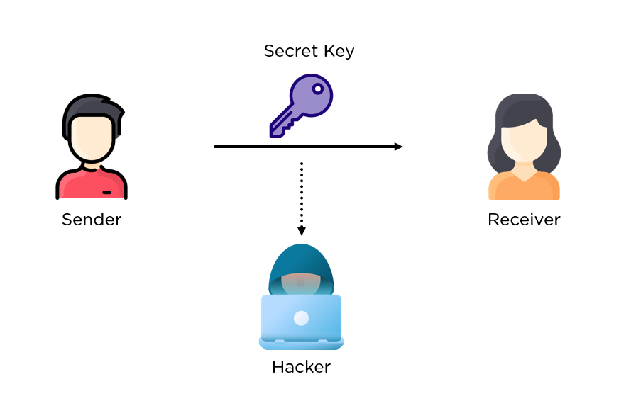

Sender and recipient exchange a secret key, how can it be conceiled from an interceptor

## Public Key

- What if Alice and Bob could share part of their key (readable by anyone) without compromising secrecy?
  - Alice encrypts with her secret key, then sends the message to Bob.
  - Bob encrypts again with his secret key and returns the message to Alice.
  - Alice decrypts with her secret key and sends the message back to Bob.
  - Finally, Bob decrypts with his key and is able to read the plaintext message.

## Problem

1. Alice encrypts,
2. Bob encrypts,
3. Alice decrypts,
4. Bob decrypts.

Symmetric ciphers don’t work like this. - You need to take off your shoes in order to take off your socks.

## Diffie-Helman Key Exchange

- Key exchange process proposed by Whitfield Diffie and Martin Hellman in 1976.
- Also discovered by Merkle, independently by James HW Ellis, Clifford Cocks, Malcolm J, Williamson at GCHQ in 1969, although this was not revealed until 1997.
- Used to provide forward secrecy in TLS.

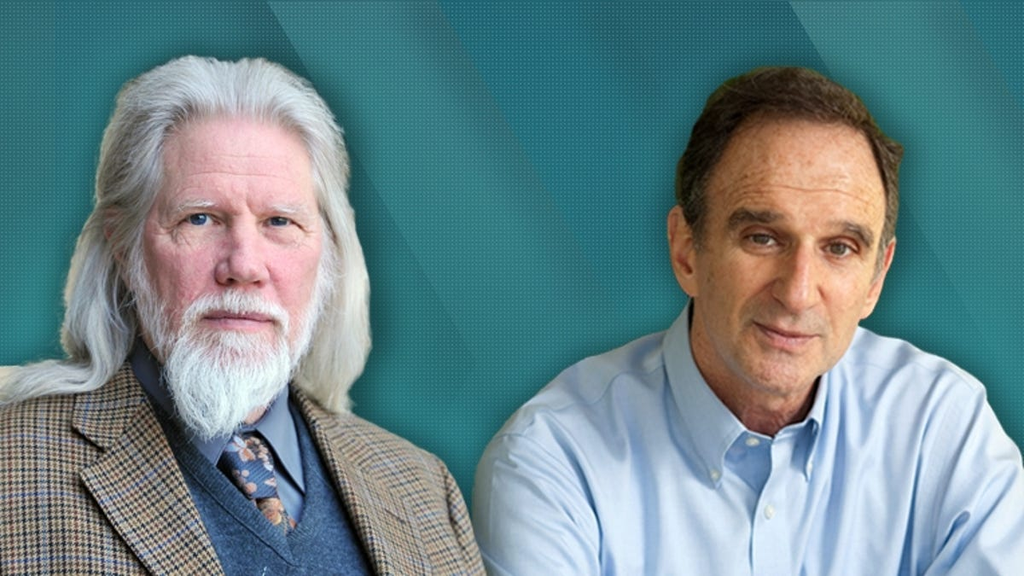

Photo of Diffie and Hellman

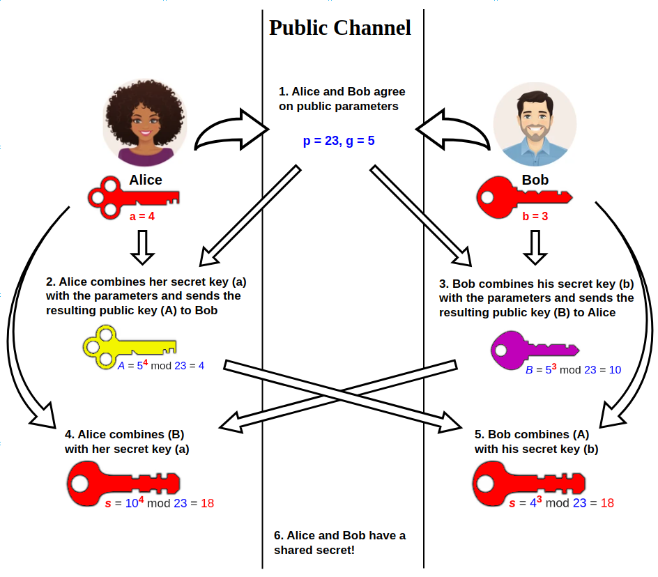

Diagram of DH key exchange

## Colour analogy

- Alice and Bob agree on a *public colour*, which they publish. Say, *red*.
- They also choose *private colours*. Say *yellow* and *blue*.
- They each mix their private colour with the public colour, making *orange* and *purple* respectively, and exchange those.
- Alice adds Bob’s mixture to her private colour, and Bob adds Alice’s mixture to his private colour. They geta *sludgy brownish* mixture.
- Crucially, Alice and Bob have the same final colour.

## One-way functions

- Mathematical operations which are easy to do, but difficult to undo.
- Real-life examples include
  - scrambling an egg
  - mixing paint
- In the previous example, it was easy for Alice and Bob to mix their colours, a third party only sees the publically available information, and it should be very difficult to extract the private colours from the mixtures.

## One-way functions for encryption

- Bob wants to send a secret message to Alice
- Alice sends Bob her *public key*, information accessible by anyone, including Oscar.
- Bob uses Alice’s public key and a one-way encryption function to encrypt his message.
- Alice receives the encrypted message from Bob.
- Only alice has the *private key*, allowing only her to easily undo the one-way function.
- Without the private key, the best way to undo Alice’s one-way function is brute force.

## The search for a one-way function

- Diffie-Hellman-Merkle relies on exponentiation modulo some prime number.
- However, DHM did not specify a one-way function.
- Three MIT researchers, Ron Rivest, Adi Shamir and Leonard Adelman searched for a one-way function, trying many different candidates over the course of a year.
- The function should be easy to compute but difficult to invert.
- Rivest and Shamir, computer scientists, suggested many possible functions, Adelman, a mathematician crushed their dreams by pointing out their flaws.

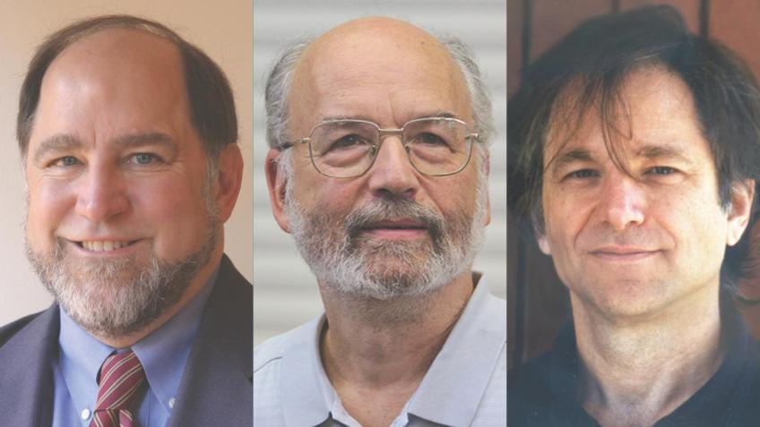

Photo of Rivest, Shamir and Adelman

## Drunken Insomnia Breakthrough

- Many approaches were tried and at one point they thought it was impossible.
- They spent Passover 1977 at a friend’s house, drank lots of wine and returned home at around midnight.
- Rivest couldn’t sleep, so he laid on the sofa with a maths textbook, thinking about one-way functions.
- By morning, he had written most of the paper.

## A paper and a patent

- RSA cryptosystem (names appearing in the same order as on the paper), was patented (granted to MIT) in 1983, U.S. Patent 4,405,829. Released to the public in 2000, after the patent expired.
- System published in Scientific American’s Mathematical Games in Augest 1977, four months before patent was submitted, so the patent was not legal outside the U.S.
- Clifford Cocks at GCHQ described a similar system in an internal communication in 1973, not declassified until 1997.

## How it works

- RSA relies on modular (clock) arithmetic.
- Remainder on division by some number, here \(12\).
- Examples
  - \(3 \mod 12 = 3\) of course,
  - \(16 \mod 12 = 4\),
  - \(37 \mod 12 = 1\).
- If two numbers have the same remainder, then we write \(3 \equiv 15 \equiv 27 \equiv ... \mod 12\) and say “3 is congruent to 15 modulo 12”.

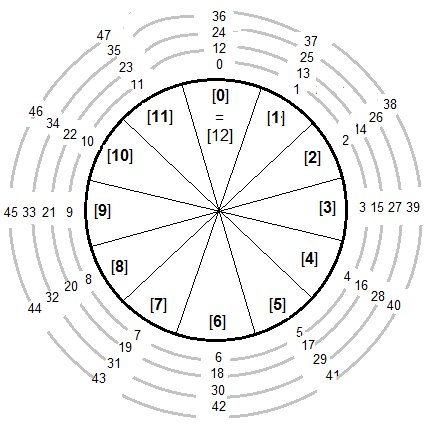

Demonstrates clock arithmetic

## How it works

- Bob wants to send a secret message, say \(x =4\), to Alice.
- Alice creates a private and public key.
  - She *publishes* \((e, n) = (5, 14)\).
  - And keeps \(d = 11\) secret.
- Bob computes \(y = x^e \mod n = 4^5 \mod 14 = 1024 \mod 14 = 2\) and sends this to Alice.
- To decrypt, Alice computes \(x' = y^d \mod n = 2^11 \mod 14 = 2048 \mod 14 = 4\)

## But how does Alice create her key?

- Pick 2 prime numbers (hundreds of digits)
  - \(p = 2, q = 7, n = p\cdotq = 14\).
- Work out the Phi function:
  - \(\phi(n)\) how many numbers between \(1\) and \(n\) are *co-prime* with \(n\).
- \(p\), \(q\), and \(\phi(n)\) must be kept secret

| Number | Factors with 2 | Factors with 7 |
| --- | --- | --- |
| 2 | Yes |  |
| 3 |  |  |
| 4 | Yes |  |
| 5 |  |  |
| 6 | Yes |  |
| 7 |  | Yes |
| 8 | Yes |  |
| 9 |  |  |
| 10 | Yes |  |
| 11 |  |  |
| 12 | Yes |  |
| 13 |  |  |
| 14 | Yes | Yes |

## Shortcut to phi

- Listing and counting is alright for \(14\), but \(p\) and \(q\) should have hundreds of digits.
- Magic!
  - \(\phi(n) = \phi(p\cdot q) = (p-1)\cdot(q-1)\)
  - \(\phi(14) = \phi(2\cdot7) = (2-1)\cdot(7-1) = 1 \cdot 6\).

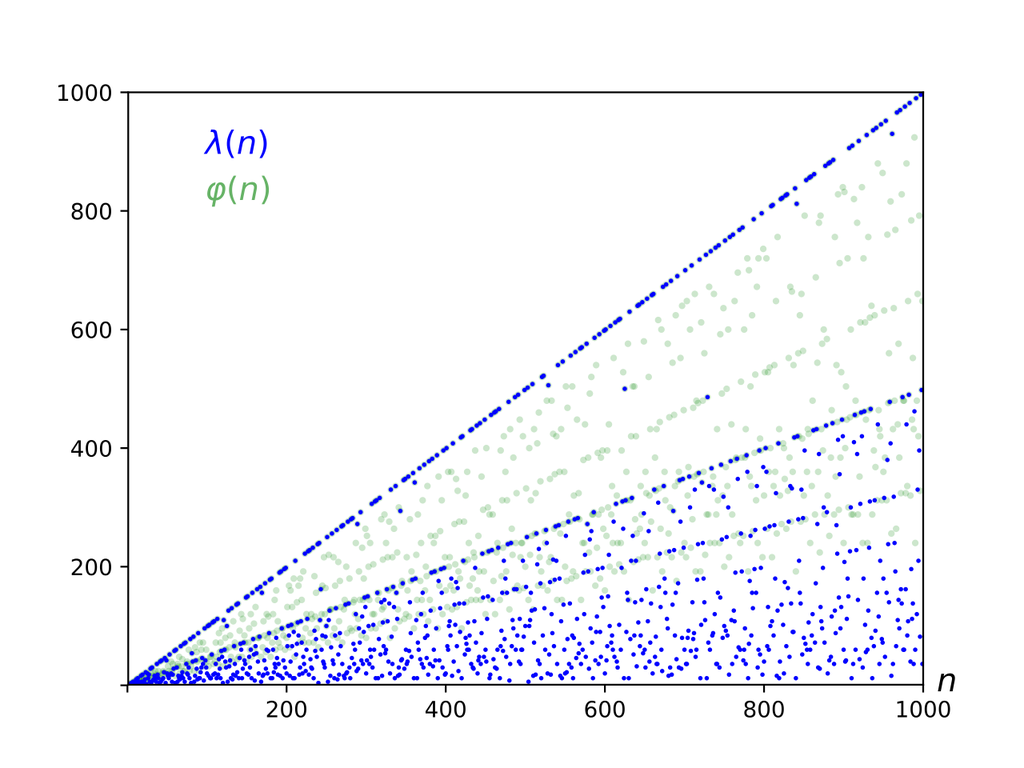

Carmichael is preferred, because it gives smaller values.

## Encryption exponent

- Pick \(e\)
  1. \(1 < e < \phi(n)\)
  2. Must be co-prime with \(n\) and \(\phi(n)\).
- We have \(1, 3, 5\) coprime with \(14\), but \(3\) is not co-prime with \(6 = \phi(14)\).
  - Choose \(e = 5\).

## Computing \(d\)

- Now work out \(d\),
  1. \(d \cdot e = 1 \mod \phi(n)\)

| Multiple of \(5\) | Mod \(6\) | Multiplier |
| --- | --- | --- |
| 5 | 5 | 1 |
| 10 | 4 | 2 |
| 15 | 3 | 3 |
| 20 | 2 | 4 |
| 25 | 1 | 5 |
| 30 | 0 | 6 |
| 35 | 5 | 7 |
| 40 | 4 | 8 |
| 45 | 3 | 9 |
| 50 | 2 | 10 |
| 55 | 1 | 11 |
| 60 | 0 | 12 |

## All thanks to Fermat

> If \(p\) is a prime and \(a\) is any integer not divisible by \(p\), then \(a^{p − 1} − 1\) is divisible by \(p\).

Proof: (https://www.cs.sjsu.edu/~stamp/CS265/SecurityEngineering/chapter5_SE/RSAmath.html)

## The RSA Problem

- RSA relies on the fact that \(p\), \(q\) and \(\phi(n)\) are kept secret.
- The RSA problem asks “can we easily find \(p\) and \(q\), or \(\phi(n)\) knowing only \(n\)”?
- It can be reduced to asking “can we decompose very large numbers into their prime factors efficiently?”
- Currently an unsolved computational problem, but we assume nobody can do it yet.

## Lab Task

- Pick a cryptosystem, do some research and present the following:
  - Some history.
  - How the system works, including what makes it secure.
  - Methods of attack / how it was broken.
- Alternatively, choose a cyber attack, do some research and present
  - How the attack was achieved,
  - Impact of the attack
  - Measures put in place to prevent it happening again.